# Assignment 04, Introduction to Data Science

Author

Hailey Wellenstein and Zujaja Baig

# Introduction to assignment

## Source of data:

[World Bank Databank](https://databank.worldbank.org/reports.aspx?source=2&Topic=1)

## Data cleaning:

```r
#Data cleaning
library(tidyverse)
library(readxl)
WB_Agriculture_Indicators <- read_excel("data/WB Agriculture Indicators.xlsx",
                                        sheet = "Data")

WB_Agriculture_Indicators <- WB_Agriculture_Indicators %>%
  rename(series_name = 'Series Name',
         series_code = 'Series Code',
         country = 'Country Name',
         country_code ='Country Code'
         )

WB_Agriculture_Indicators <- WB_Agriculture_Indicators %>%
  pivot_longer(
    cols = -c(series_name, series_code, country, country_code),
    names_to = "year",
    values_to = "value"
  )

WB_Agriculture_Indicators$year <- as.numeric(WB_Agriculture_Indicators$year)
WB_Agriculture_Indicators$value <- as.numeric(WB_Agriculture_Indicators$value)
```

# First Visualization

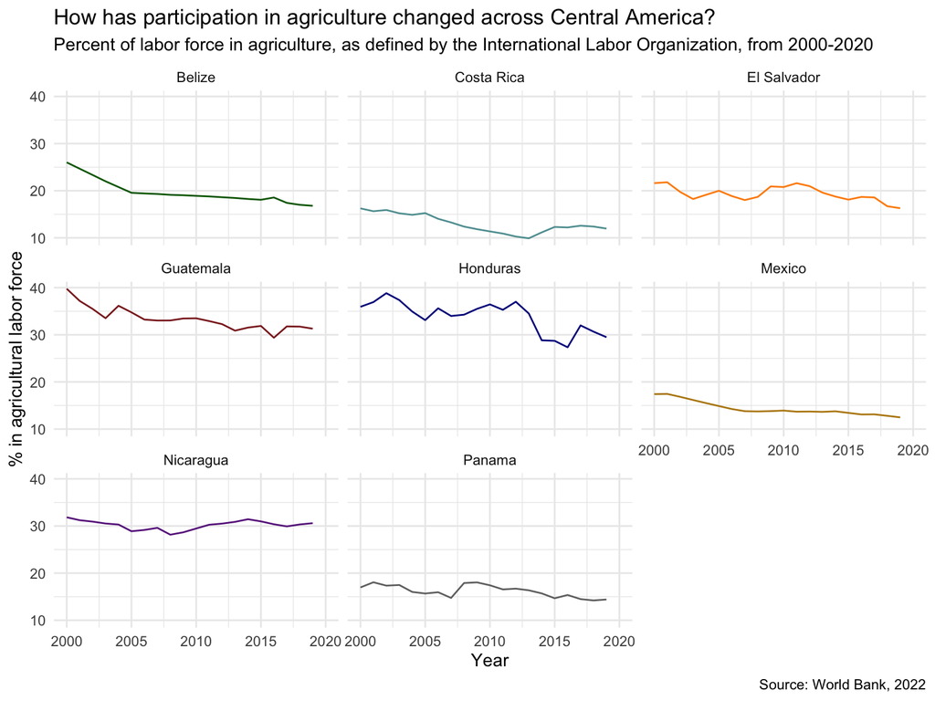

```r
WB_Agriculture_Indicators %>%
  filter(series_code == "SL.AGR.EMPL.ZS") %>%
  filter(!is.na(value)) %>%
  filter(country == "Mexico" | country == "Guatemala" | country == "Honduras"
         | country == "Nicaragua" | country == "El Salvador" | country == "Costa Rica" |
           country == "Panama" | country == "Belize") %>%
  ggplot(mapping = aes(x = year, y = value, group = country)) +
        geom_line(mapping = aes(color = country), show.legend = FALSE) +
  facet_wrap(~country) +
  scale_x_continuous(limits = c(2000,2020)) +
  scale_color_manual(values = c("darkgreen", "cadetblue", "darkorange", "brown4", "darkblue", "darkgoldenrod", "darkorchid4", "gray44"))+
  theme_minimal() +
  labs(title = "How has participation in agriculture changed across Central America?",
       subtitle = "Percent of labor force in agriculture, as defined by the International Labor Organization, from 2000-2020",
       x = "Year",
       y = "% in agricultural labor force",
       caption = "Source: World Bank, 2022")
```

# Second Visualization

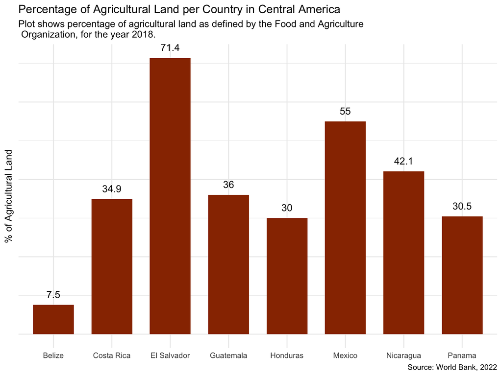

```r
WB_Agriculture_Indicators %>%
  filter(year == 2018) %>%
  filter(series_code == "AG.LND.AGRI.ZS") %>%
  filter(!is.na(value)) %>%
  filter(country == "Mexico" | country == "Guatemala" | country == "Honduras"
         | country == "Nicaragua" | country == "El Salvador" | country == "Costa Rica" |
           country == "Panama" | country == "Belize") %>%
  ggplot(mapping = aes(x = country, y = value)) +
  geom_col(fill = "#993300", width = .7) +
  geom_text(aes(label = round(value,1)), vjust = -1, size = 4) +
  theme_minimal() +
  theme(axis.text.y = element_blank())+
  labs(title = "Percentage of Agricultural Land per Country in Central America",
       subtitle = "Plot shows percentage of agricultural land as defined by the Food and Agriculture\n Organization, for the year 2018.",
       x=NULL,
       y = "% of Agricultural Land",
       caption = "Source: World Bank, 2022" )
```

The second visualization builds upon the policy question of the first visualization which is “What the state of agriculture intensity is in Central America?”. This visualization shows the percentage of agricultural land per country for Central America. The results of this plot are interesting because the countries that had the highest participation in agriculture are not the same as those who have the most agricultural land. For example, Guatemala and Honduras had high levels of labor force participation in agriculture, but in this graph we can see that it is actually El Salvador and Mexico that have the most agricultural land. This would be a good opportunity for further investigation to better understand the agricultural land and labor patterns and the over or under-usage of land in these countries.

# Third Visualization

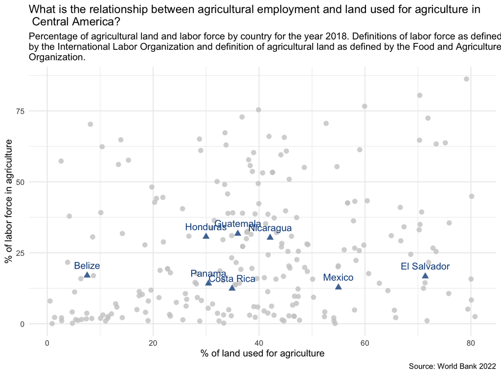

```r
x <- WB_Agriculture_Indicators %>%
  filter(year == 2018) %>%
  filter(series_code == "AG.LND.AGRI.ZS") %>%
  filter(!is.na(value)) %>%
  pivot_wider(
    names_from = series_code,
    values_from = value
  )   %>%
  select(country, country_code, AG.LND.AGRI.ZS)

y <- WB_Agriculture_Indicators %>%
  filter(year == 2018) %>%
  filter(series_code == "SL.AGR.EMPL.ZS") %>%
  filter(!is.na(value)) %>%
  pivot_wider(
    names_from = series_code,
    values_from = value
  )   %>%
  select(country, country_code, SL.AGR.EMPL.ZS)


scatterplot_df <- left_join(x = x, y = y, by = "country_code")

scatterplot_df <- scatterplot_df %>%
  mutate(centam = if_else(
    (country.x == "Mexico" | country.x == "Guatemala" | country.x == "Honduras"
         | country.x == "Nicaragua" | country.x == "El Salvador" | country.x == "Costa Rica" |
           country.x == "Panama" | country.x == "Belize"),
    true = 1,
    false = 0
  ))

scatterplot_df %>%
  filter(!is.na(SL.AGR.EMPL.ZS)) %>%
  filter(!is.na(AG.LND.AGRI.ZS)) %>%
  ggplot(mapping = aes(
    x= AG.LND.AGRI.ZS,
    y = SL.AGR.EMPL.ZS,
    color = as.character(centam))) +
  geom_point (aes(shape = centam == 1),size = 2.5, alpha = .8, show.legend = FALSE) +
  geom_text(aes(label = if_else(centam == "1", country.x, "")), show.legend = FALSE, vjust = -1)+
  scale_color_manual(values = c("0" = "gray80", "1" = "dodgerblue4"))+
  theme_minimal()+
  labs( title = "What is the relationship between agricultural employment and land used for agriculture in\n Central America?",
        subtitle = "Percentage of agricultural land and labor force by country for the year 2018. Definitions of labor force as defined \nby the International Labor Organization and definition of agricultural land as defined by the Food and Agriculture \nOrganization.",
        x = "% of land used for agriculture",
        y = "% of labor force in agriculture",
        caption = "Source: World Bank 2022")
```

The third visualization takes the variables of interest from the first two visualizations and compares both the percentage of the labor force in agriculture and the land used for agriculture for each country. The grey data points on the graph represent non-Central American countries and show how their statistics relate to general global patterns of agriculture workforce and land usage. The viewer is able to see that there is not a strong or consistent trend across the Central American region, which is in-line with the insights from the previous graphs.

# Fourth Visualization

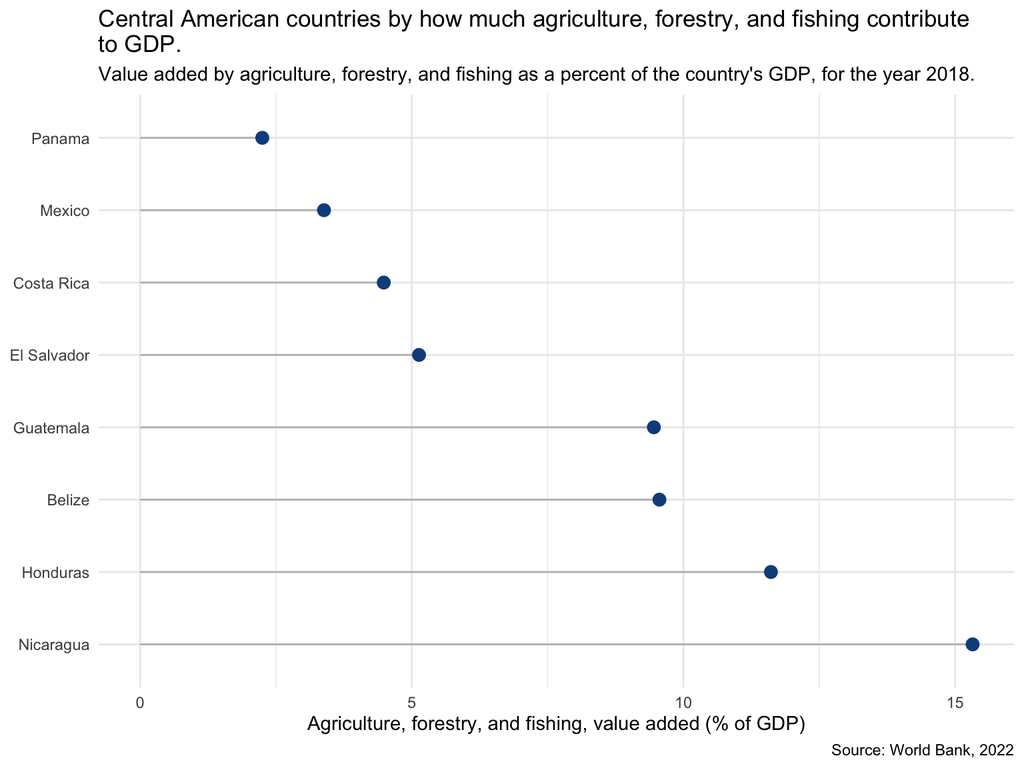

```r
my_factor_levels <- c("Nicaragua", "Honduras", "Belize", "Guatemala", "El Salvador", "Costa Rica", "Mexico", "Panama")
WB_Agriculture_Indicators$country <- factor(WB_Agriculture_Indicators$country, levels = my_factor_levels)


WB_Agriculture_Indicators %>%
  filter(year == 2018) %>%
  filter(series_code == "NV.AGR.TOTL.ZS") %>%
  filter(country == "Mexico" | country == "Guatemala" | country == "Honduras"
         | country == "Nicaragua" | country == "El Salvador" | country == "Costa Rica" |
           country == "Panama" | country == "Belize") %>%
  filter(!is.na(value)) %>%
  ggplot(mapping = aes(x = country, y = value)) +
  geom_segment(aes(x=country, xend=country, y=0, yend=value), color = "grey") +
  geom_point(size = 3, color = "dodgerblue4")+
  coord_flip() +
  theme_minimal() +
  labs(title = "Central American countries by how much agriculture, forestry, and fishing contribute \nto GDP.",
       subtitle = "Value added by agriculture, forestry, and fishing as a percent of the country's GDP, for the year 2018.",
       x = NULL,
       y = "Agriculture, forestry, and fishing, value added (% of GDP)",
       caption = "Source: World Bank, 2022"
  )
```

The fourth visualization brings together the information from the first three visualizations by asking how much the labor and land used for agricultural purposes in a country contribute to the country’s revenue. This is measured by the value added by agriculture, forestry and fishing as a percentage of the country’s GDP. Unsurprisingly, the countries that have a lot of individuals working in agriculture depend most highly on agriculture, forestry and fishing for revenue. Belize rises in these rankings in comparison to the previous graphs perhaps because this measure also includes forestry and fishing, as the earlier graphs focused only on agriculture. Overall, these set of graphs would help policymakers to better understand the state of agricultural activity and production across Central America.